# Documentación en R

Práctica Guiada

### Introducción

El objetivo de esta clase es comenzar a trabajar utilizando el formato RNotebook para realizar reportes compilados directamente en RStudio, de forma tal que nuestro trabajo pueda quedar documentado y ser fácilmente compartido con otras personas.

Para esto utilizaremos un dataframe del paquete **datos**. Deberemos instalarlo en caso de no contar con el mismo, y luego cargarlo con la función `library()`. En particular, utilizaremos los datos de **encuesta**, que consiste en una muestra de variables categóricas de la Encuesta Social General de EE.UU.

```r
encuesta <- datos::encuesta
```

El dataframe cuenta con 21.483 observaciones y 9 variables.

### Explorando los datos

La muestra refiere a información obtenida entre 2000 y 2014. Se presentan datos sobre estado civil, raza, ingresos, partido político de pertenencia, religión, y cantidad de horas dedicadas a mirar televisión, para personas de entre 18 y 89 años.

#### Religión

En primer lugar, nos interesa ver la distribución en términos de la **religión** de las personas, haciendo énfasis en aquellas más populares.

| religion | cantidad |
| --- | --- |
| Protestante | 10846 |
| Católica | 5124 |
| Ninguna | 3523 |
| Cristiana | 689 |
| Judía | 388 |
| Otra | 224 |
| Budismo | 147 |
| Inter o no confesional | 109 |
| Musulmana/Islam | 104 |
| Cristiana ortodoxa | 95 |

[output cut: 5 more lines]

Puede verse que aquella que cuenta con más seguidores es la religión Protestante, con 10.846 fieles.

#### Estado Civil

También podemos visualizar la distribución del **estado civil** de las personas.

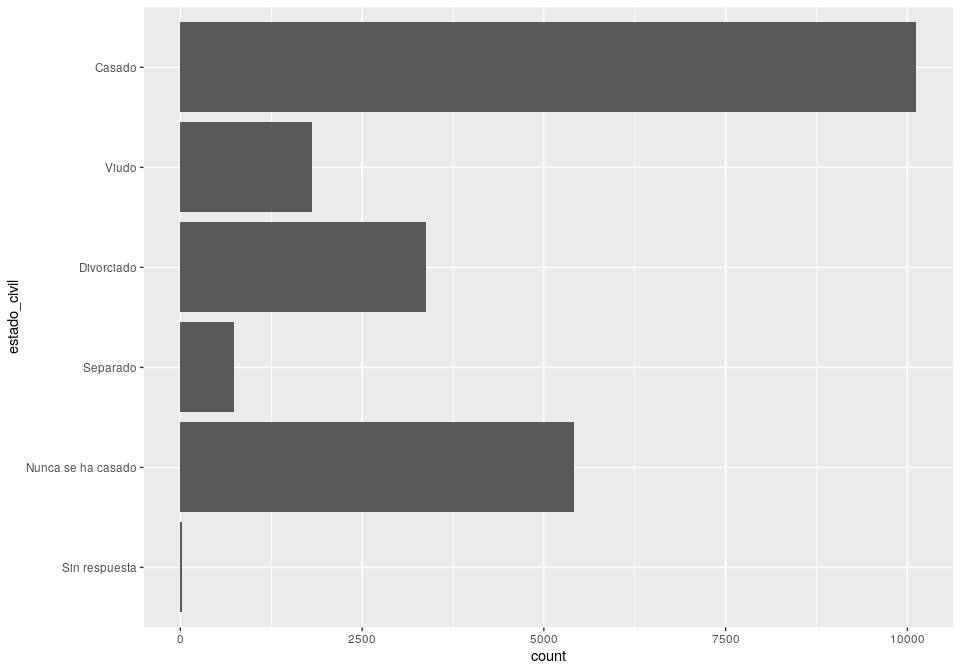

Vemos que la mayoría de las personas (10.117 en total) responde “Casado” cuando se indaga sobre su estado civil.

#### Partido político

La encuesta también nos permite conocer sobre las pertenencias partidarias de los individuos.

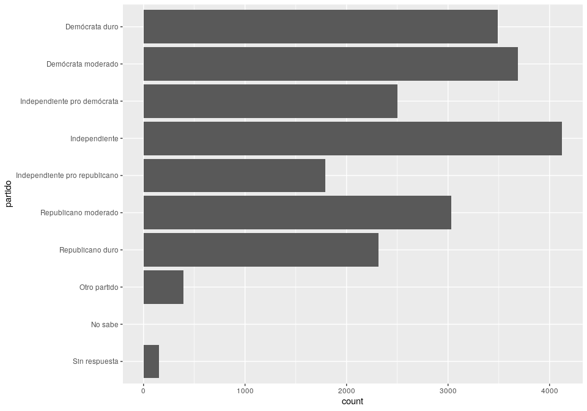

#### Horas de exposición a la televisión

A partir de los datos, sabemos que los individuos miran la televisión, en promedio, durante 3 horas por día. A continuación se presenta toda la distribución de la variable:

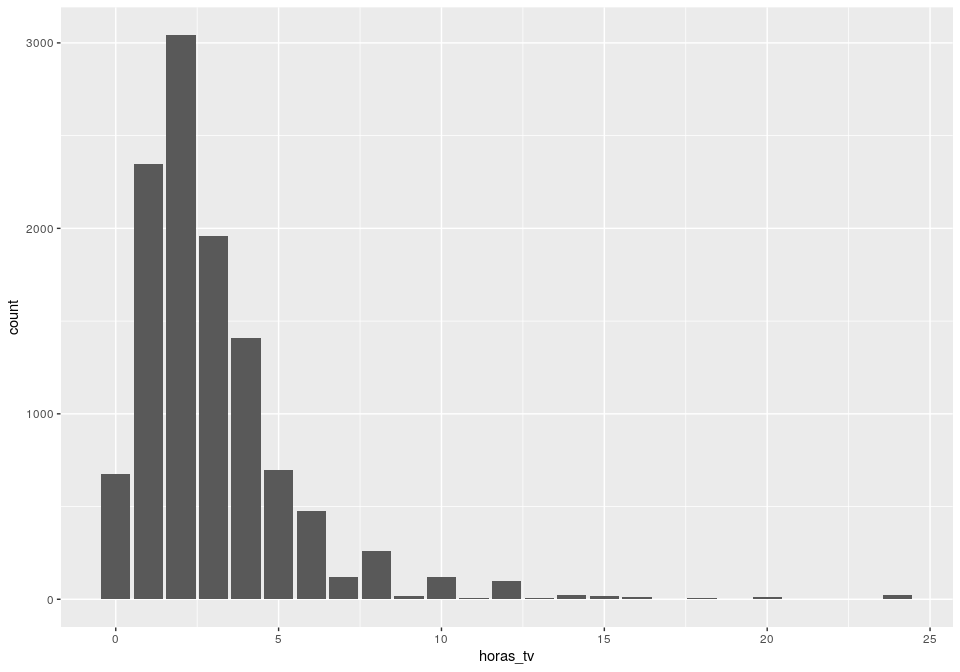